[figure not shown]

# COPERNICUS MARINE SERVICE : Marine Data 4 Africa

# Analysing the West African Moonsoon System

**General Note 1**: Execute each cell through the button from the top MENU (or keyboard shortcut `Shift` + `Enter`).  
**General Note 2**: If, for any reason, the kernel is not working anymore, in the top MENU, click on the button. Then, in the top MENU, click on "Run" and select "Run All Above Selected Cell".

- 1. Introduction
- 2. Set up Python
  - 2.1 Required Python modules
- 3. Data
  - 3.1 Presentation of the product used
  - 3.2 Accessing the data : the Copernicus ToolBox
- 4. Seasonal Patterns of currents and sea water temperatures
- 5. Correlations between sea-surface temperature and currents
- 6. Impacts on Primary Production
- 7. Long Term Trends in the West African Moonsoon System
  - 7.1 Current Dynamics
  - 7.2 Sea Surface Temperatures
  - 7.3 Primary Production
- 8. Exercises
- 9. Conclusion

# 1. Introduction

Go back to the "Table of contents"

Marine data plays a critical role in Africa, a continent where oceanic and climatic dynamics significantly impact economies, ecosystems, and livelihoods. With over 26,000 km of coastline, Africa relies on its marine resources for fisheries, transportation, energy, and biodiversity conservation. Furthermore, climate variability and extreme weather events—such as tropical storms, coastal erosion, and rising sea levels—necessitate accurate ocean monitoring to better anticipate their effects and develop adaptive strategies. Understanding oceanic conditions is essential for sustainable development, disaster risk management, and the long-term resilience of coastal communities.

One of the most influential climatic systems affecting West Africa is the West African Monsoon (WAM), which governs rainfall patterns and directly influences agriculture, food security, and both terrestrial and marine ecosystems. This system results from complex interactions between the Atlantic Ocean and atmospheric circulation over the Sahara. A key factor in its variability is the Gulf of Guinea, where sea surface temperature fluctuations can modulate the monsoon’s intensity and distribution. Warmer or cooler waters in this region can shift rainfall patterns, potentially causing droughts or floods with significant socio-economic consequences.

Studying long-term trends in key oceanic variables—such as sea surface temperature, salinity, ocean currents, and atmospheric pressure—can provide invaluable insights into climate change impacts and natural variability in the region. By analyzing historical data, scientists can detect patterns that influence the monsoon system and predict future climatic shifts with greater accuracy. This long-term perspective is crucial for improving climate models, enhancing early warning systems, and informing policies on coastal protection, fisheries management, and sustainable development. In a rapidly changing climate, investing in sustained marine observations will be essential for building resilience and ensuring the well-being of millions of people who depend on West Africa’s coastal and oceanic resources.

| </center> |
| --- |
| Schematic view of the West African Monsoon System adopted from Lafore et al. (2010). FIT stands for ITD (InterTropical Discontinuity), “Air chaud Saharien” stands for ‘Warm Saharian Air”, JEA stands f… |

In this notebook, we will focus on sea water temperature, ocean currents, and primary production. We will analyse how these variables interact with each other and what are the long-term trends associated with them.

# 2. Set up Python

Go back to the "Table of contents"

## 2.1 Required Python modules

Go back to the "Table of contents"

The Jupyter Notebook must be set up with all the necessary available tools from the Jupyter Notebook ecosystem. Here is the list of the modules we will be using in this exercise.

| Module name | Description |
| --- | --- |
| **numpy** | [NumPy](https://numpy.org/) is the fundamental package for scientific computing with Python and for managing ND-arrays. |
| **pandas** | [Pandas](https://pandas.pydata.org/docs/) is a powerful package to manage with data tables. |
| **xarray** | [Xarray](http://xarray.pydata.org/en/stable/) is a very user friendly library to manipulate NetCDF files within Python. It introduces labels in the form of dimensions, coordinates and attributes on to… |
| **scipy** | [SciPy](https://scipy.org/) is an open-source Python library used for scientific and technical computing, providing tools for mathematics, statistics, optimization, and signal processing, making it es… |
| **matplotlib** | [Matplotlib](https://matplotlib.org/) is a Python 2D plotting library which produces high quality figures. |
| **cartopy** | [Cartopy](https://scitools.org.uk/cartopy/docs/latest/) is a library for plotting maps and geospatial data analyses in Python. |
| **datetime** | [Datetime](https://docs.python.org/3/library/datetime.html) supplies classes for manipulating dates and times |

```python
# To avoid warning messages
import warnings
warnings.filterwarnings('ignore')

# Import libraries
import numpy as np
import xarray as xr
import matplotlib.pyplot as plt
import matplotlib.colors as colors
import matplotlib.patches as mpatches
import cartopy.crs as ccrs
import cartopy.feature as cfeature
import glob
import datetime
import pandas as pd
import os

from scipy.stats import linregress, pearsonr
from matplotlib.colors import ListedColormap
import matplotlib.patches as mpatches
```

# 3. Data

Go back to the "Table of contents"

## 3.1 Presentation of the product used

Go back to the "Table of contents"

We will derive the sea water temperature and the currents from a reanalysis product from the CMEMS catalogue : [Global Ocean Physics Reanalysis](https://data.marine.copernicus.eu/product/GLOBAL_MULTIYEAR_PHY_001_030/description).

This system mainly relies on the real-time global forecasting model from CMEMS. It uses the NEMO platform, which is driven at the surface by ECMWF ERA-Interim data, later replaced by ERA5 for recent years. Observations are incorporated using a simplified Kalman filter. It assimilates data from satellite altimeters (Sea Level Anomaly), Sea Surface Temperature, Sea Ice Concentration, and in-situ temperature and salinity profiles. Additionally, a 3D-VAR scheme helps correct slow-developing large-scale biases in temperature and salinity.

The table below summarizes the main characteristics of the dataset :

| Parameter | Value |
| --- | --- |
| **Variables used** | thetao, uo, vo |
| **Product identifier** | [GLOBAL_MULTIYEAR_PHY_001_030](https://data.marine.copernicus.eu/product/GLOBAL_MULTIYEAR_PHY_001_030/description) |
| **Spatial resolution** | 0.083° × 0.083° |
| **Temporal resolution** | Daily, Monthly |
| **Temporal coverage** | 1 Jan 1993 to 28 Jan 2025 |

[figure not shown]

In our case, we will only download **monthly** data. It will allow us to study the trends across the 30 years of data available, while maintaining manageable file sizes.

**For detailed information about the product, please consult the document:** [Product User Manual (PUM)](https://documentation.marine.copernicus.eu/PUM/CMEMS-GLO-PUM-001-030.pdf)

**For information about the quality of the product, please consult the document:** [Quality Information Document (QUID)](https://documentation.marine.copernicus.eu/QUID/CMEMS-GLO-QUID-001-030.pdf)

We will derive the primary production from satellite observations : [Global Ocean Colour Plankton MY L4 monthly observations](https://data.marine.copernicus.eu/product/OCEANCOLOUR_GLO_BGC_L4_MY_009_108/description).

This productis derived from multiple satellite data inputs : SeaWiFS, MODIS, MERIS, VIIRS-SNPP, OLCI-S3A and OLCI-S3B.

The table below summarizes the main characteristics of the dataset :

| Parameter | Value |
| --- | --- |
| **Variables used** | CHL |
| **Product identifier** | [OCEANCOLOUR_GLO_BGC_L4_MY_009_108](https://data.marine.copernicus.eu/product/OCEANCOLOUR_GLO_BGC_L4_MY_009_108/description) |
| **Spatial resolution** | 4 x 4 km |
| **Temporal resolution** | Monthly |
| **Temporal coverage** | 1 Sep 1997 to 1 Dec 2024 |

[figure not shown]

**For detailed information about the product, please consult the document:** [Product User Manual (PUM)](https://documentation.marine.copernicus.eu/PUM/CMEMS-OC-PUM.pdf)

**For information about the quality of the product, please consult the document:** [Quality Information Document (QUID)](https://documentation.marine.copernicus.eu/QUID/CMEMS-OC-QUID-009-107to108.pdf)

## 3.2 Accessing the data : the Copernicus ToolBox

Go back to the "Table of contents"

The [Copernicus Marine Toolbox](https://help.marine.copernicus.eu/en/articles/7949409-copernicus-marine-toolbox-introductionis) a new free tool that allows users to explore product metadata information, subset datasets, and download original files from producers, all without quotas. The procedure of downloading Copernicus Marine products is explained in details [here](https://help.marine.copernicus.eu/en/collections/9054839-main-functionalities). The data needed for the training is entirely downloadable using the following Python cells.

First, we import the Toolbox. Make sure to have activated the pre-installed CMEMS Python Kernel v4, which contains the Toolbox library. You can select it by clicking at the top right hand corner of this window.

[figure not shown]

```python
import copernicusmarine
```

```python
# In this sell, we define the boundaries of our area of interest

lat_min = 0
lat_max = 10
lon_min =  -5
lon_max = 10
```

```python
# SST and currents

copernicusmarine.subset(
dataset_id="cmems_mod_glo_phy_my_0.083deg_P1M-m",
variables=[ "thetao", "uo", "vo"],
minimum_longitude=lon_min,
maximum_longitude=lon_max,
minimum_latitude=lat_min,
maximum_latitude=lat_max,
start_datetime="1993-01-01T00:00:00",
end_datetime="2020-12-31T00:00:00",
minimum_depth=0.49402499198913574,
maximum_depth=0.49402499198913574,
output_directory = "data"
)
```

```
username:
```

```
password:
```

```
INFO - 2025-02-25T10:14:20Z - Dataset version was not specified, the latest one was selected: "202311"
INFO - 2025-02-25T10:14:20Z - Dataset part was not specified, the first one was selected: "default"
INFO - 2025-02-25T10:14:23Z - Service was not specified, the default one was selected: "arco-time-series"
INFO - 2025-02-25T10:14:23Z - Downloading using service arco-time-series...
INFO - 2025-02-25T10:14:24Z - <xarray.Dataset> Size: 177MB
Dimensions:    (depth: 1, latitude: 121, longitude: 181, time: 336)
Coordinates:
  * depth      (depth) float32 4B 0.494
  * latitude   (latitude) float32 484B 0.0 0.08333 0.1667 ... 9.833 9.917 10.0
  * longitude  (longitude) float32 724B -5.0 -4.917 -4.833 ... 9.833 9.917 10.0
  * time       (time) datetime64[ns] 3kB 1993-01-01 1993-02-01 ... 2020-12-01
Data variables:
    thetao     (time, depth, latitude, longitude) float64 59MB dask.array<chunksize=(68, 1, 64, 64), meta=np.ndarray>
    uo         (time, depth, latitude, longitude) float64 59MB dask.array<chunksize=(68, 1, 64, 64), meta=np.ndarray>
    vo         (time, depth, latitude, longitude) float64 59MB dask.array<chunksize=(68, 1, 64, 64), meta=np.ndarray>
Attributes: (12/15)
    Conventions:                   CF-1.6
    area:                          GLOBAL
    contact:                       servicedesk.cmems@mercator-ocean.eu
    credit:                        E.U. Copernicus Marine Service Information...
    dataset:                       global-reanalysis-001-030-monthly
    institution:                   Mercator Ocean
    ...                            ...
    product_user_manual:           http://marine.copernicus.eu/documents/PUM/...
    quality_information_document:  http://marine.copernicus.eu/documents/QUID...
    references:                    http://marine.copernicus.eu
    source:                        MERCATOR GLORYS12V1
    title:                         Monthly mean fields for product GLOBAL_REA...
    copernicusmarine_version:      1.2.2
INFO - 2025-02-25T10:14:24Z - Estimated size of the dataset file is 168.521 MB.
Do you want to proceed with download? [Y/n]:
```

```
INFO - 2025-02-25T10:14:59Z - Writing to local storage. Please wait...
```

```
INFO - 2025-02-25T10:15:01Z - Successfully downloaded to data/cmems_mod_glo_phy_my_0.083deg_P1M-m_thetao-uo-vo_5.00W-10.00E_0.00N-10.00N_0.49m_1993-01-01-2020-12-01_(1).nc
```

```
PosixPath('data/cmems_mod_glo_phy_my_0.083deg_P1M-m_thetao-uo-vo_5.00W-10.00E_0.00N-10.00N_0.49m_1993-01-01-2020-12-01_(1).nc')
```

```python
# chla :

# biogeochemical model - chlorophyll
copernicusmarine.subset(
dataset_id="c3s_obs-oc_glo_bgc-plankton_my_l4-multi-4km_P1M",
 variables=["CHL"],
 minimum_longitude=lon_min,
 maximum_longitude=lon_max,
 minimum_latitude=lat_min,
 maximum_latitude=lat_max,
start_datetime="1998-01-01T00:00:00",
 end_datetime="2023-12-31T00:00:00",
output_directory = "data"
)
```

```
username:
```

```
password:
```

```
INFO - 2025-02-12T13:43:13Z - Dataset version was not specified, the latest one was selected: "202207"
INFO - 2025-02-12T13:43:13Z - Dataset part was not specified, the first one was selected: "default"
INFO - 2025-02-12T13:43:14Z - Service was not specified, the default one was selected: "arco-time-series"
INFO - 2025-02-12T13:43:14Z - Downloading using service arco-time-series...
INFO - 2025-02-12T13:43:14Z - <xarray.Dataset> Size: 108MB
Dimensions:    (time: 312, latitude: 240, longitude: 360)
Coordinates:
  * latitude   (latitude) float32 960B 0.02083 0.0625 0.1042 ... 9.938 9.979
  * longitude  (longitude) float32 1kB -4.979 -4.938 -4.896 ... 9.938 9.979
  * time       (time) datetime64[ns] 2kB 1998-01-01 1998-02-01 ... 2023-12-01
Data variables:
    CHL        (time, latitude, longitude) float32 108MB dask.array<chunksize=(61, 128, 128), meta=np.ndarray>
Attributes: (12/39)
    Conventions:               CF-1.7
    Creation_time:             08:52:23 UTC
    Metadata_Conventions:      Unidata Dataset Discovery v1.0
    Naming_authority:          CMEMS
    Netcdf_version_id:         V4
    citation:                  The licensees should respect the Copernicus Ma...
    ...                        ...
    stop_date:                 1997-09-30
    stop_time:                 23:59:00 UTC
    summary:                   These data are Level-4 satellite data (Level 4...
    title:                     c3s_obs-oc_glo_bgc-plankton_my_l4-multi-4km_P1M
    westernmost_longitude:     -180
    copernicusmarine_version:  1.2.2
INFO - 2025-02-12T13:43:14Z - Estimated size of the dataset file is 102.889 MB.
Do you want to proceed with download? [Y/n]:
```

```
INFO - 2025-02-12T13:43:17Z - Writing to local storage. Please wait...
```

```
INFO - 2025-02-12T13:43:18Z - Successfully downloaded to data/c3s_obs-oc_glo_bgc-plankton_my_l4-multi-4km_P1M_CHL_4.98W-9.98E_0.02N-9.98N_1998-01-01-2023-12-01.nc
```

```
PosixPath('data/c3s_obs-oc_glo_bgc-plankton_my_l4-multi-4km_P1M_CHL_4.98W-9.98E_0.02N-9.98N_1998-01-01-2023-12-01.nc')
```

Both datasets have been downloaded in the `data/`directory. Let's first open the product containing the SST and currents variables.

# 4. Seasonal Patterns of currents and sea water temperatures

Go back to the "Table of contents"

```python
ds = xr.open_dataset('data/cmems_mod_glo_phy_my_0.083deg_P1M-m_thetao-uo-vo_5.00W-10.00E_0.00N-10.00N_0.49m_1993-01-01-2020-12-01.nc')
ds
```

```
<xarray.Dataset> Size: 177MB
Dimensions:    (depth: 1, latitude: 121, longitude: 181, time: 336)
Coordinates:
  * depth      (depth) float32 4B 0.494
  * latitude   (latitude) float32 484B 0.0 0.08333 0.1667 ... 9.833 9.917 10.0
  * longitude  (longitude) float32 724B -5.0 -4.917 -4.833 ... 9.833 9.917 10.0
  * time       (time) datetime64[ns] 3kB 1993-01-01 1993-02-01 ... 2020-12-01
Data variables:
    thetao     (time, depth, latitude, longitude) float64 59MB ...
    uo         (time, depth, latitude, longitude) float64 59MB ...
    vo         (time, depth, latitude, longitude) float64 59MB ...
Attributes: (12/15)
    Conventions:                   CF-1.6
    area:                          GLOBAL
    contact:                       servicedesk.cmems@mercator-ocean.eu
    credit:                        E.U. Copernicus Marine Service Information...
    dataset:                       global-reanalysis-001-030-monthly
    institution:                   Mercator Ocean
    ...                            ...
    product_user_manual:           http://marine.copernicus.eu/documents/PUM/...
    quality_information_document:  http://marine.copernicus.eu/documents/QUID...
    references:                    http://marine.copernicus.eu
    source:                        MERCATOR GLORYS12V1
    title:                         Monthly mean fields for product GLOBAL_REA...
    copernicusmarine_version:      1.2.2
```

The dataset has 4 dimensions : depth, latitude, longitude and time. However, we retrieved only one depth level from the product : 0.5 meters beneath the surface. It is therefore nos use to keep this "depth" dimension in the dataset. To simplify an xarray dataset that has dimensions with single levels, use the **squeeze** method.

```python
ds = ds.squeeze()
ds
```

```
<xarray.Dataset> Size: 177MB
Dimensions:    (latitude: 121, longitude: 181, time: 336)
Coordinates:
    depth      float32 4B 0.494
  * latitude   (latitude) float32 484B 0.0 0.08333 0.1667 ... 9.833 9.917 10.0
  * longitude  (longitude) float32 724B -5.0 -4.917 -4.833 ... 9.833 9.917 10.0
  * time       (time) datetime64[ns] 3kB 1993-01-01 1993-02-01 ... 2020-12-01
Data variables:
    thetao     (time, latitude, longitude) float64 59MB ...
    uo         (time, latitude, longitude) float64 59MB ...
    vo         (time, latitude, longitude) float64 59MB ...
Attributes: (12/15)
    Conventions:                   CF-1.6
    area:                          GLOBAL
    contact:                       servicedesk.cmems@mercator-ocean.eu
    credit:                        E.U. Copernicus Marine Service Information...
    dataset:                       global-reanalysis-001-030-monthly
    institution:                   Mercator Ocean
    ...                            ...
    product_user_manual:           http://marine.copernicus.eu/documents/PUM/...
    quality_information_document:  http://marine.copernicus.eu/documents/QUID...
    references:                    http://marine.copernicus.eu
    source:                        MERCATOR GLORYS12V1
    title:                         Monthly mean fields for product GLOBAL_REA...
    copernicusmarine_version:      1.2.2
```

To complete our dataset, we cill compute the total current velocity by combining the eastward and northward components, using the following formula :

Current Speed= $\sqrt{uo²+vo²}$

```python
ds['cur_speed'] = np.sqrt(ds.uo**2 + ds.vo**2)
```

```python
ds_seas = ds.groupby("time.season").mean()
ds_seas
```

```
<xarray.Dataset> Size: 3MB
Dimensions:    (season: 4, latitude: 121, longitude: 181)
Coordinates:
    depth      float32 4B 0.494
  * latitude   (latitude) float32 484B 0.0 0.08333 0.1667 ... 9.833 9.917 10.0
  * longitude  (longitude) float32 724B -5.0 -4.917 -4.833 ... 9.833 9.917 10.0
  * season     (season) object 32B 'DJF' 'JJA' 'MAM' 'SON'
Data variables:
    thetao     (season, latitude, longitude) float64 701kB 27.88 27.89 ... nan
    uo         (season, latitude, longitude) float64 701kB -0.2103 ... nan
    vo         (season, latitude, longitude) float64 701kB 0.01664 ... nan
    cur_speed  (season, latitude, longitude) float64 701kB 0.2536 0.2517 ... nan
Attributes: (12/15)
    Conventions:                   CF-1.6
    area:                          GLOBAL
    contact:                       servicedesk.cmems@mercator-ocean.eu
    credit:                        E.U. Copernicus Marine Service Information...
    dataset:                       global-reanalysis-001-030-monthly
    institution:                   Mercator Ocean
    ...                            ...
    product_user_manual:           http://marine.copernicus.eu/documents/PUM/...
    quality_information_document:  http://marine.copernicus.eu/documents/QUID...
    references:                    http://marine.copernicus.eu
    source:                        MERCATOR GLORYS12V1
    title:                         Monthly mean fields for product GLOBAL_REA...
    copernicusmarine_version:      1.2.2
```

The time coordinate has been replaced by a "season" coordinate, with 4 values : DJF (December Janury February : Winter), JJA (June July August : Summer), MAM (March April May : Spring), SON (September October November : Fall).

Lets visualize the computed climatologies.

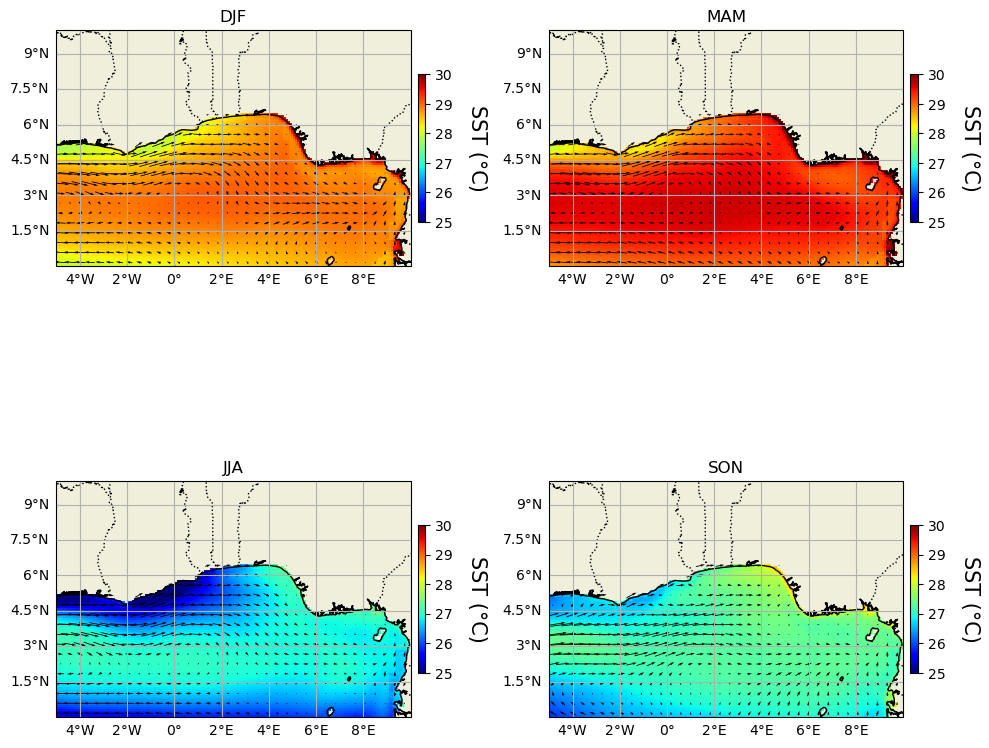

```python
# display seasonal current patterns

f = plt.figure(figsize=(10,10))


seasons = ["DJF", "MAM", "JJA", "SON"]

ds_seas_coarse = ds_seas.coarsen(latitude=5, longitude=5, boundary="trim").mean()
x = ds_seas_coarse.longitude.data
y = ds_seas_coarse.latitude.data

for c, season in enumerate(seasons):

    ax = plt.subplot(2,2,c+1, projection = ccrs.PlateCarree())
    ax.coastlines()
    ax.add_feature(cfeature.LAND, zorder=1, edgecolor='k')
    ax.add_feature(cfeature.BORDERS, linestyle=':')
    ax.set_extent([lon_min, lon_max, lat_min, lat_max])
    gl = ax.gridlines(crs=ccrs.PlateCarree(), draw_labels=True)
    gl.right_labels = False
    gl.top_labels = False
    ax.set_ylabel('Latitude (°)')
    ax.set_ylabel('Longitude (°)')

    im = ax.pcolor(ds_seas.longitude.data, ds_seas.latitude.data, ds_seas.sel(season=season).thetao.data, cmap='jet', vmin=25, vmax=30)
    cbar = f.colorbar(im, ax=ax,fraction=0.02, pad=0.02)                                            # add the colorbar
    cbar.set_label('SST (°C)', rotation=270,fontsize=15, labelpad=25)
    ax.set_title(f'{season}')

    qv = ax.quiver(x, y, ds_seas_coarse.sel(season=season)["uo"], ds_seas_coarse.sel(season=season)["vo"], pivot='mid', angles='xy')

plt.tight_layout()
```

On the plots, the arrows show the currents and the colors show the Sea Surface Temperature. We can see a clear cooling phenomenon during boreal summer, especially near the coast.

During the boreal summer (June–September), the West African Monsoon intensifies, and the southeast trade winds strengthen along the equator. These winds push surface waters away from the coast due to Ekman transport, a process where the wind-driven movement of water layers causes surface waters to be deflected offshore. Therefore, deeper (and colder) waters rise to replace the displaced water.

# 5. Correlations between sea-surface temperature and currents

Go back to the "Table of contents"

Xarray allows you to correlate variables from a dataset along chosen dimensions. Let's correlate SST and current velocity to see if the result supports the upwelling phenomenon observed in the Guld of Guinea.

```python
# correlation between sst and ocean currents

correlation = xr.corr(ds.thetao, ds.cur_speed, dim='time')
correlation
```

```
<xarray.DataArray (latitude: 121, longitude: 181)> Size: 175kB
array([[-0.15801573, -0.15628661, -0.15448839, ...,         nan,
                nan,         nan],
       [-0.14482649, -0.14312716, -0.14133721, ...,         nan,
                nan,         nan],
       [-0.13067067, -0.12884682, -0.12693284, ...,         nan,
                nan,         nan],
       ...,
       [        nan,         nan,         nan, ...,         nan,
                nan,         nan],
       [        nan,         nan,         nan, ...,         nan,
                nan,         nan],
       [        nan,         nan,         nan, ...,         nan,
                nan,         nan]])
Coordinates:
    depth      float32 4B 0.494
  * latitude   (latitude) float32 484B 0.0 0.08333 0.1667 ... 9.833 9.917 10.0
  * longitude  (longitude) float32 724B -5.0 -4.917 -4.833 ... 9.833 9.917 10.0
```

We have computed correlation along the *time* coordinate. Therefore our result is a correlation map : with a correlation coefficient between SST and current velocity for each pixel. Let's visualize this.

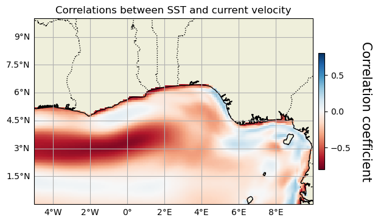

```python
f=plt.figure()

ax = plt.axes(projection = ccrs.PlateCarree())
ax.coastlines()
ax.add_feature(cfeature.LAND, zorder=1, edgecolor='k')                             # add land mask
ax.add_feature(cfeature.BORDERS, linestyle=':')
ax.set_extent([lon_min, lon_max, lat_min, lat_max])
gl = ax.gridlines(crs=ccrs.PlateCarree(), draw_labels=True)
gl.right_labels = False                                                            # remove latitude labels on the right
gl.top_labels = False
ax.set_ylabel('Latitude (°)')
ax.set_ylabel('Longitude (°)')

im = ax.pcolor(correlation.longitude.data, correlation.latitude.data, correlation.data, cmap='RdBu', vmin=-0.8, vmax=0.8)
cbar = f.colorbar(im, ax=ax,fraction=0.02, pad=0.02)                                            # add the colorbar
cbar.set_label('Correlation coefficient', rotation=270,fontsize=15, labelpad=25)
ax.set_title('Correlations between SST and current velocity')

plt.tight_layout()
```

There is a strong inverse correlation between SST and current speed near the coast (area in dark red) : this highlights the idea that strong currents in this area tend to bring colder waters to the surface, confirming that current-driven upwelling is a key factor in SST variability in this region. Other areas show weaker negative or positive correlations, which may indicate the influence of other processes.

# 6. Impacts on Primary Production

Go back to the "Table of contents"

Let's now look at the seasonal patterns of the chlorophyll-a concentrations to see if it is consistent with the SST variations.

```python
# correlation SST cholophyll

ds_chl = xr.open_dataset('data/c3s_obs-oc_glo_bgc-plankton_my_l4-multi-4km_P1M_CHL_4.98W-9.98E_0.02N-9.98N_1998-01-01-2023-12-01.nc')
ds_chl
```

```
<xarray.Dataset> Size: 108MB
Dimensions:    (time: 312, latitude: 240, longitude: 360)
Coordinates:
  * latitude   (latitude) float32 960B 0.02083 0.0625 0.1042 ... 9.938 9.979
  * longitude  (longitude) float32 1kB -4.979 -4.938 -4.896 ... 9.938 9.979
  * time       (time) datetime64[ns] 2kB 1998-01-01 1998-02-01 ... 2023-12-01
Data variables:
    CHL        (time, latitude, longitude) float32 108MB ...
Attributes: (12/39)
    Conventions:               CF-1.7
    Creation_time:             08:52:23 UTC
    Metadata_Conventions:      Unidata Dataset Discovery v1.0
    Naming_authority:          CMEMS
    Netcdf_version_id:         V4
    citation:                  The licensees should respect the Copernicus Ma...
    ...                        ...
    stop_date:                 1997-09-30
    stop_time:                 23:59:00 UTC
    summary:                   These data are Level-4 satellite data (Level 4...
    title:                     c3s_obs-oc_glo_bgc-plankton_my_l4-multi-4km_P1M
    westernmost_longitude:     -180
    copernicusmarine_version:  1.2.2
```

Computing the seasonal climatologies:

```python
ds_chl_seas = ds_chl.groupby("time.season").mean()
ds_chl_seas
```

```
<xarray.Dataset> Size: 1MB
Dimensions:    (season: 4, latitude: 240, longitude: 360)
Coordinates:
  * latitude   (latitude) float32 960B 0.02083 0.0625 0.1042 ... 9.938 9.979
  * longitude  (longitude) float32 1kB -4.979 -4.938 -4.896 ... 9.938 9.979
  * season     (season) object 32B 'DJF' 'JJA' 'MAM' 'SON'
Data variables:
    CHL        (season, latitude, longitude) float32 1MB 0.2084 0.2181 ... nan
Attributes: (12/39)
    Conventions:               CF-1.7
    Creation_time:             08:52:23 UTC
    Metadata_Conventions:      Unidata Dataset Discovery v1.0
    Naming_authority:          CMEMS
    Netcdf_version_id:         V4
    citation:                  The licensees should respect the Copernicus Ma...
    ...                        ...
    stop_date:                 1997-09-30
    stop_time:                 23:59:00 UTC
    summary:                   These data are Level-4 satellite data (Level 4...
    title:                     c3s_obs-oc_glo_bgc-plankton_my_l4-multi-4km_P1M
    westernmost_longitude:     -180
    copernicusmarine_version:  1.2.2
```

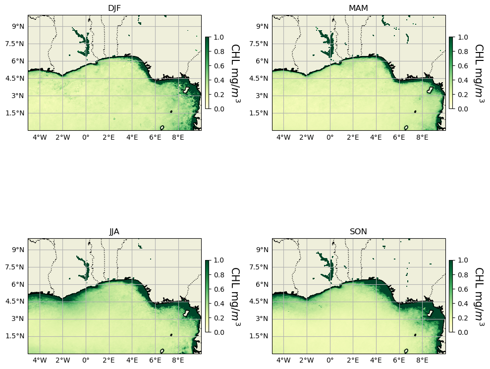

```python
# display seasonal current patterns

f = plt.figure(figsize=(10,10))


seasons = ["DJF", "MAM", "JJA", "SON"]

ds_seas_coarse = ds_seas.coarsen(latitude=5, longitude=5, boundary="trim").mean()
x = ds_seas_coarse.longitude.data
y = ds_seas_coarse.latitude.data

for c, season in enumerate(seasons):

    ax = plt.subplot(2,2,c+1, projection = ccrs.PlateCarree())
    ax.coastlines()
    ax.add_feature(cfeature.LAND, zorder=1, edgecolor='k')                             # add land mask
    ax.add_feature(cfeature.BORDERS, linestyle=':')
    ax.set_extent([lon_min, lon_max, lat_min, lat_max])
    gl = ax.gridlines(crs=ccrs.PlateCarree(), draw_labels=True)
    gl.right_labels = False                                                            # remove latitude labels on the right
    gl.top_labels = False
    ax.set_ylabel('Latitude (°)')
    ax.set_ylabel('Longitude (°)')

    im = ax.pcolor(ds_chl_seas.longitude.data, ds_chl_seas.latitude.data, ds_chl_seas.sel(season=season).CHL.data, cmap='YlGn', vmin=0, vmax=1)
    cbar = f.colorbar(im, ax=ax,fraction=0.02, pad=0.02)                                            # add the colorbar
    cbar.set_label('CHL mg/$m^3$', rotation=270,fontsize=15, labelpad=25)
    ax.set_title(f'{season}')

plt.tight_layout()
```

The chlorophyll-a concentration is higher during the boreal summer season (June July August). Indeed, the rise of deeper waters brings nutrients to the surface, driving phytoplankton growth.

# 7. Long Term Trends in the West African Moonsoon System

Go back to the "Table of contents"

In this sections, we analyse whether or not the ocean variables in the Gulf of Guinea. We will look at the trends in SST, current velocity, and chlorophyll-a concentration. This will allow us to evaluate the potentials impacts of climate change in the region: potential rise of the temperatures, shifting of the current dynamics and variations in biomass.

In order to highlight long-term trends, we can smooth out the seasonal pattern of the data by resampling the monthly dataset and compute the yearly means of SSt current speed, and chl-a concentrations. We can either use the **groupby** or the **resample** functions from xarray.

```python
ds_avg_y = ds.mean(dim=['latitude','longitude']).groupby('time.year').mean()
ds_chl_avg_y = ds_chl.groupby("time.year").mean().mean(dim=['latitude','longitude'], skipna = True)
```

## 7.1 Current Dynamics

Go back to the "Table of contents"

Using the linear regression module from **scipy**, we now compute the linear trends for the current variables : horizontal component, vertical component and total speed. The **linregress** function will also yield the correlation coefficient and p-value to evaluate the significance of the trend. You can read the associated [documentation](https://docs.scipy.org/doc/scipy/reference/generated/scipy.stats.linregress.html) to know more about the function and its outputs.

```python
slope1, intercept1, r1, p1, se1 = linregress(ds_avg_y.year.data,  ds_avg_y.cur_speed.data)
slope2, intercept2, r2, p2, se2 = linregress(ds_avg_y.year.data,  ds_avg_y.uo.data)
slope3, intercept3, r3, p3, se3 = linregress(ds_avg_y.year.data,  ds_avg_y.vo.data)

trend_vals1 = ds_avg_y.year.data*slope1 + intercept1
trend_vals2 = ds_avg_y.year.data*slope2 + intercept2
trend_vals3 = ds_avg_y.year.data*slope3 + intercept3
```

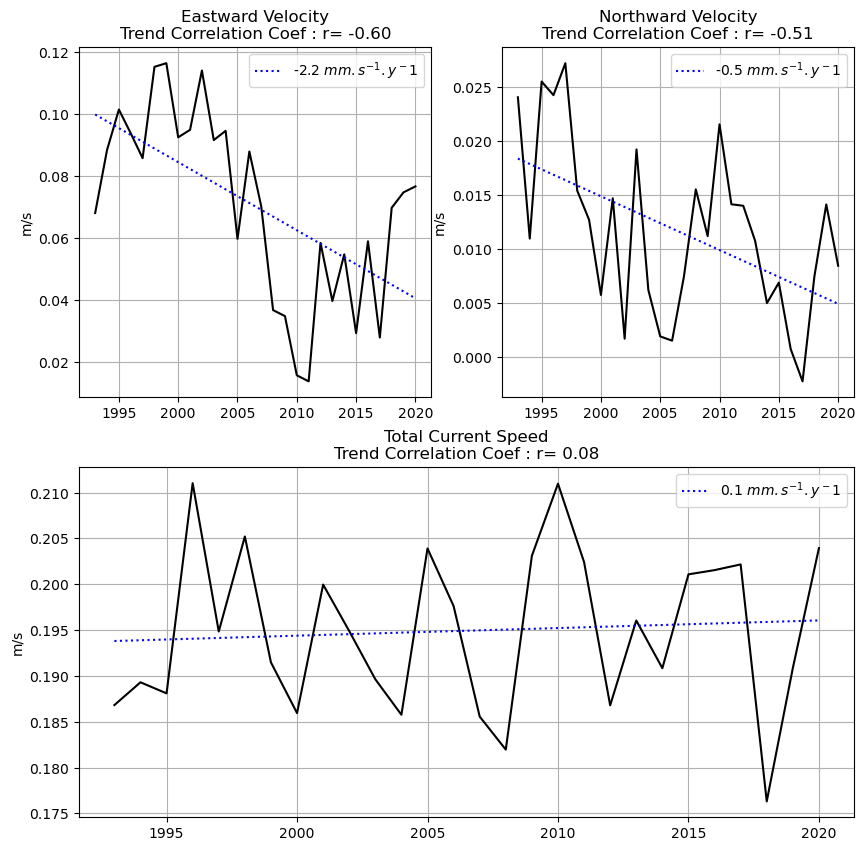

```python
fig = plt.figure(figsize=(10, 10))

ax1 = plt.subplot(221)
ax1.plot(ds_avg_y.year.data, ds_avg_y.uo.data, color='k')
ax1.plot(ds_avg_y.year.data, trend_vals2, color='b', linestyle=':', label='%.1f $mm.s^{-1}.{y^-1}$' % (1000*slope2))
ax1.set_title('Eastward Velocity\nTrend Correlation Coef : r= %.2f' %r2)
ax1.set_ylabel('m/s')
ax1.grid(True)
ax1.legend()

ax2 = plt.subplot(222)
ax2.plot(ds_avg_y.year.data, ds_avg_y.vo.data, color='k')
ax2.plot(ds_avg_y.year.data, trend_vals3, color='b', linestyle=':', label='%.1f $mm.s^{-1}.{y^-1}$' % (1000*slope3))
ax2.set_title('Northward Velocity\nTrend Correlation Coef : r= %.2f' %r3)
ax2.set_ylabel('m/s')
ax2.grid(True)
ax2.legend()


ax3 = plt.subplot(212)
ax3.plot(ds_avg_y.year.data, ds_avg_y.cur_speed.data, color='k')
ax3.plot(ds_avg_y.year.data, trend_vals1, color='b', linestyle=':', label='%.1f $mm.s^{-1}.{y^-1}$' % (1000*slope1))
ax3.set_title('Total Current Speed\nTrend Correlation Coef : r= %.2f' %r1)
ax3.set_ylabel('m/s')
ax3.grid(True)
ax3.legend()
```

We can see that although both components seem to show declining speed over the years, the total speed doesn't undergo any significant changes. Looking more closely at the plots we observe that the variabilities of the two components compensate each other, therefore we cannot conclude on a weakening or strengthening of the current velocity in the Gulf of Guinea.

## 7.2 Sea Surface Temperatures

Go back to the "Table of contents"

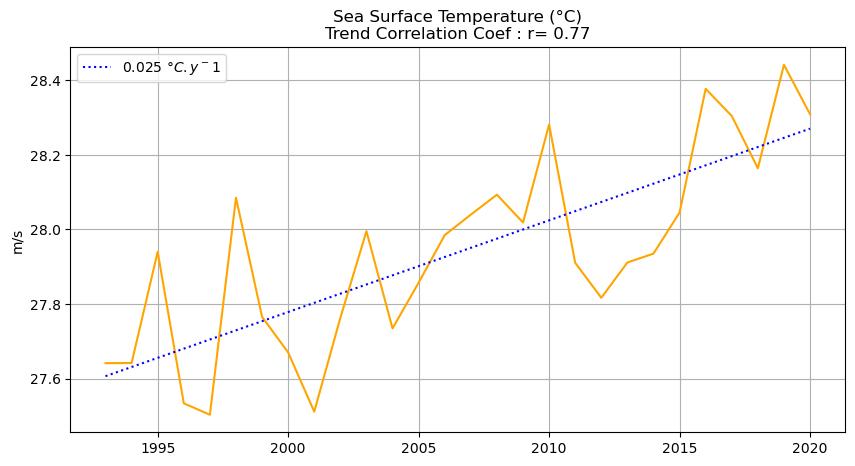

```python
slope, intercept, r, p, se = linregress(ds_avg_y.year.data,  ds_avg_y.thetao.data)
trend_vals = ds_avg_y.year.data*slope + intercept


fig, ax = plt.subplots(figsize=(10, 5))

ax.plot(ds_avg_y.year.data, ds_avg_y.thetao.data, color='orange')
ax.plot(ds_avg_y.year.data, trend_vals, color='b', linestyle=':', label='%.3f $°C.{y^-1}$' % slope)
ax.set_title('Sea Surface Temperature (°C)\nTrend Correlation Coef : r= %.2f' %r)
ax.set_ylabel('m/s')
ax.grid(True)
ax.legend()
```

We observe a steady increase in SST over the years, at a rate that could imply potential changes for the local marine ecosystems. There is also a high inter-annual variability that could be due to other processes.

## 7.3 Primary Production

Go back to the "Table of contents"

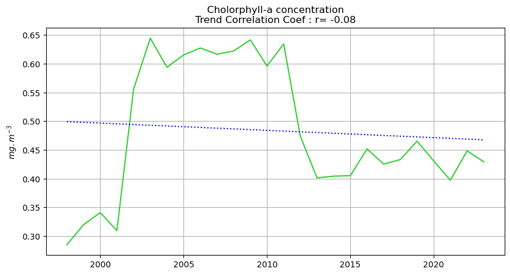

```python
slope, intercept, r, p, se = linregress(ds_chl_avg_y.year.data,  ds_chl_avg_y.CHL.data)
trend_vals = ds_chl_avg_y.year.data*slope + intercept


fig, ax = plt.subplots(figsize=(10, 5))

ax.plot(ds_chl_avg_y.year.data, ds_chl_avg_y.CHL.data, color='limegreen')
ax.plot(ds_chl_avg_y.year.data, trend_vals, color='b', linestyle=':')
ax.set_title('Cholorphyll-a concentration\nTrend Correlation Coef : r= %.2f' %r)
ax.set_ylabel('$mg.m^{-3}$')
ax.grid(True)
```

You have reached the end of this tutorial, here are a few exercises to complete the training !

# 8. Exercises

Go back to the "Table of contents"

Here is a set of exercises we propose for you to go further into the analysis. There are 2 levels depending on how much Python code you need to write to answer the questions. If you need help, do not hesitate to contact the service desk: **[servicedesk.cmems@mercator-ocean.eu](servicedesk.cmems@mercator-ocean.eu)**! **Beginners** : - In [Section 4](#4.-Seasonal-Patterns-of-currents-and-sea-water-temperatures), we displayed the seasonal patterns of Sea Surface Temperatures. Can you instead display the total current speed ? **Intermediate** : - In [section 7](#7.-Long-Term-Trends-in-the-West-African-Moonsoon-System), we have computed the long-term trends taking into account the entire years. However we also showed that there were key seasonal patterns. Can you compute the long term trends for each season ? - There are other key systems on the world where analysing such variables could yield interesting results. Examples : Humboldt Current System, the Western Pacific Warm Pool or the Benguela Current system. Remeber that the products used in this training cover the whole world.

# 9. Conclusion

Go back to the "Table of contents"

In this notebook, you learned to access CMEMS data through the Copernicus Marine Service ToolBox, and to explore it. You then learned to identify seasonal patterns in scientific data, correlate several variables and compute long-term linear trends in spatially averaged timeseries.

**Congratulations !!**

And thank you for your attention! :)

We hope you enjoyed this Jupyter Notebook training on Africa.

This training course is over but we'd love to hear from you about how we could improve it (topics, tools, storytelling, format, speed etc). If you have any question, do not hesitate to contact us at servicedesk.cmems@mercator-ocean.eu !